# A01212611_thermo_Hwk03

Q4001 Thermodynamics of Materials  
Homework 3  
Osamu Katagiri - A01212611@itesm.mx - CEM

```python
#******************************************************************************#
# Futures
%matplotlib inline
# from __future__ import unicode_literals
# from __future__ import print_function

# Generic/Built-in
import datetime
import argparse

# Other Libs
from IPython.display import display, Image
import matplotlib.pyplot as plt
import numpy as np

# Owned
# from nostalgia_util import log_utils
# from nostalgia_util import settings_util
__authors__   = ["Osamu Katagiri - A01212611@itesm.mx"]
__copyright__ = "None"
__credits__   = ["Marcelo Videa - mvidea@itesm.mx"]
__license__   = "None"
__status__    = "Under Work"
#******************************************************************************#
```

## Exercise 1

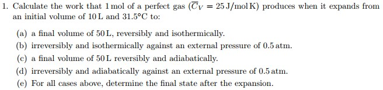

```python
display(Image(filename='./directions/1.jpg'))
```

### For 1.a & 1.e (Isothermal Reversible Expansion)

$$ W_{\text{REV}}=-R n T \text{ln}\left(\frac{V_f}{V_i}\right) $$

where:  
$ n = 1 mol$  
$ R = 8.314 J K^{-1} mol^{-1}$  
$ T = 31.5 °C$  
$ V_i = 10 L$  
$ V_f = 50 L$

$$ W_{\text{REV}}=-4076.481 J $$

$$ P_f = P_i V_i V_f^{-1} = 50657.202 Pa$$ $$ V_f = 50 L$$ $$ T_f = T_i = 304.65 K$$

### For 1.b & 1.e (Isothermal Irreversible Expansion)

$$ W_{\text{IRREV}}=-P_{\text{ext}} \left(V_f-V_i\right) $$

where:  
$ P_{\text{ext}} = 0.5 atm$  
$ V_f = 50 L$  
$ V_i = 10 L$

$$ W_{\text{IRREV}}=-20 atm L $$

as: $ 1 atm L = 101.3 J $

$$ W_{\text{IRREV}}=-2027 J $$

$$ P_f = P_{ext} = 0.5 atm = 50700 Pa $$ $$ V_f = 50 L $$ $$ T_f = T_i = 304.65 K $$

### For 1.c & 1.e (Adiabatic Reversible Expansion)

$$ P_i=\frac{n R T_i}{V_i}=\frac{(1 mol) (8.314 J K^{-1} mol^{-1}) (31.5 °C)}{(10 L)} $$$$ P_i=253286.01 Pa $$$$ \gamma =\frac{\overline{C_p}}{\overline{C_v}}=\frac{\overline{C_v}+R}{\overline{C_v}}=\frac{(25 J K^{-1} mol^{-1}) + (8.314 J K^{-1} mol^{-1})}{25 J K^{-1} mol^{-1}} $$$$ \gamma =1.33256 $$$$ P_f=\frac{P_i V_i^{\gamma }}{V_f^{\gamma }}=\frac{(253286 Pa)\ (10 L)^{1.33256}}{(50 L)^{1.33256}} $$$$ P_f=29661.406 Pa$$$$ W_{\text{REV}}=\frac{P_f V_f-P_i V_i}{\gamma -1}= \frac{(29661.406 Pa) (50x10^{-3} m^{-3}) - (253286.01 Pa) (10x10^{-3} m^{-3})}{1.33256 -1}$$

$$ W_{\text{REV}}=-3156.693 J $$

$$ P_f = 29661.406 Pa $$ $$ V_f = 50 L $$ $$ T_f = T_i V_i^{\gamma -1} {(V_f^{\gamma -1})}^{-1} = 178.382 K $$

### For 1.d & 1.e (Adiabatic Irreversible Expansion)

$$ W_{\text{IRREV}}=\text{$\Delta $U}=-P dV=n \overline{C_v} dT $$

where:  
$ n = 1 mol$  
$ \overline{C_v} = 25 J K^{-1} mol^{-1}$  
$ dT = T_f - T_i$  
$ T_i = 304.65 K$  
$ P_i = 253286.01 Pa$  
$ P_f = P_ext = 0.5 atm = 50700 Pa$

$$ T_f=\frac{T_i \left(\overline{C_v}+\frac{R P_f}{P_i}\right)}{\overline{C_p}} $$$$ T_f=243.839 K $$$$ W_{\text{IRREV}}=(1 mol) (25 J K^{-1} mol^{-1}) (T_f - T_i) $$

$$ W_{\text{IRREV}}=-1520.275 J $$

$$ P_f = P_{ext} = 0.5 atm = 50700 Pa $$ $$ V_f = \frac{(1 mol) (8.314 J K^{-1} mol^{-1}) (243.839 K)}{50700 Pa} = 40 L$$ $$ T_f = 243.839 K $$

## Exercise 2

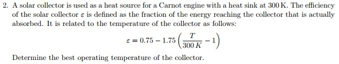

```python
display(Image(filename='./directions/2.jpg'))
```

Solar collector $\varepsilon$ is given by: $$ \varepsilon = 0.75\, -1.75 \left(\frac{T}{300 K}-1\right) $$

The Carnot engine efficiency $\eta$ is given by: $$ \eta = \frac{T}{300 K}-1 $$

The system's efficiency $\epsilon$ is given by: $$ \epsilon = \varepsilon \eta $$ $$ \epsilon = -\frac{1.75 T^{2}}{(300 K)^{2}} + \frac{4.25 T}{300 K} - 1.5 $$

Let's find $\frac{\partial \epsilon}{\partial T}$ $$ \frac{\partial \epsilon}{\partial T} = -\frac{2(1.75)}{300^{2}} T + \frac{4.25}{300}$$ $$ \frac{\partial \epsilon}{\partial T} = \frac{17}{1200} - \frac{7}{180000} T $$

## Exercise 3

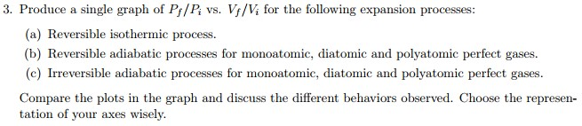

```python
display(Image(filename='./directions/3.jpg'))
```

### Function to compute the "next" pressure value for REVERSIBLE processes

$$ P=\frac{n R T^{\gamma }}{V^{\gamma }} $$

### Function to compute the "next" pressure value for IRREVERSIBLE processes

$$ \text{dU}=-P \text{dV} =n \overline{C_v}\text{dT} $$$$ n \overline{C_v} \int_{T_i}^{T_f} \, dT = -P_f \int_{V_i}^{V_f} \, dV$$$$ n \overline{C_v} (T_f - T_i) = -P_f (V_f - V_i) $$$$ n \overline{C_v} \left(\frac{P_f V_f}{n R} - \frac{P_i V_i}{n R}\right) = -P_f (V_f - V_i) $$$$ \frac{n \overline{C_v} P_f V_f}{n R} - \frac{n \overline{C_v} P_i V_i}{n R} = -P_f (V_f - V_i) $$$$ P_f \left( \frac{n \overline{C_v} V_f}{n R} + V_f - V_i \right) = \frac{n \overline{C_v} P_i V_i}{n R} $$

$$ P_f = \frac{\overline{C_v} P_i V_i}{\overline{C_v} V_f + V_f R - V_i R} $$

```
<module 'matplotlib.pyplot' from 'C:\\Users\\oskat\\Anaconda3\\lib\\site-packages\\matplotlib\\pyplot.py'>
```

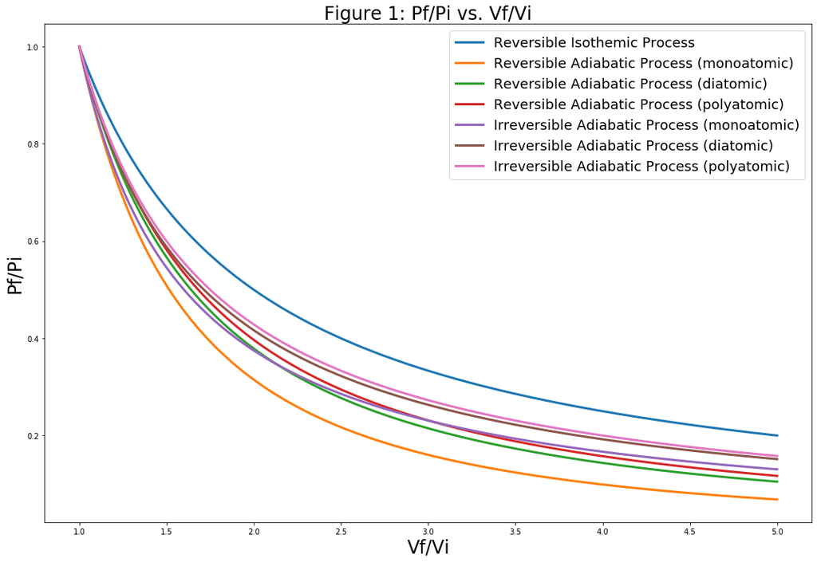

```python
# Function to compute the "next" pressure value for REVERSIBLE processes
def P_rev(n, R, T, V, gamma):
    return (n*R*(T**gamma))/(V**gamma);

# Function to compute the "next" pressure value for IRREVERSIBLE processes
def P_irrev(Cv, Pi, Vi, Vf, R):
    return (Cv*Pi*Vi)/(Cv*Vf+Vf*R-Vi*R);

# Draw the plot's workspace
n = 6;
plt.subplots(figsize=(3*n, 2*n))

# Initial State, Constants & Final Volume
Ti = 304.65; #K
Vi = 0.01; #10 L
Vf = 0.05; #50 L
V = np.linspace(Vi,Vf,1000);
n = 1; #mol
R = 8.314; #J/K mol)

# Reversible Isothemic Process
gamma = 1;
Vf = V;
Pi = P_rev(n, R, Ti, Vi, gamma);
Pf = P_rev(n, R, Ti, V, gamma);
plt.plot(Vf/Vi, Pf/Pi, '-', linewidth=3, label='Reversible Isothemic Process');

# Reversible Adiabatic Process (monoatomic)
Cv = (3/2)*R;
Cp = Cv + R;
gamma = Cp/Cv;
Vf = V;
Pi = P_rev(n, R, Ti, Vi, gamma);
Pf = P_rev(n, R, Ti, V, gamma);
plt.plot(Vf/Vi, Pf/Pi, '-', linewidth=3, label='Reversible Adiabatic Process (monoatomic)');

# Reversible Adiabatic Process (diatomic)
Cv = (5/2)*R;
Cp = Cv + R;
gamma = Cp/Cv;
Vf = V;
Pi = P_rev(n, R, Ti, Vi, gamma);
Pf = P_rev(n, R, Ti, V, gamma);
plt.plot(Vf/Vi, Pf/Pi, '-', linewidth=3, label='Reversible Adiabatic Process (diatomic)');

# Reversible Adiabatic Process (polyatomic)
Cv = 3*R;
Cp = Cv + R;
gamma = Cp/Cv;
Vf = V;
Pi = P_rev(n, R, Ti, Vi, gamma);
Pf = P_rev(n, R, Ti, V, gamma);
plt.plot(Vf/Vi, Pf/Pi, '-', linewidth=3, label='Reversible Adiabatic Process (polyatomic)');

# Irreversible Adiabatic Process (monoatomic)
Cv = (3/2)*R;
Cp = Cv + R;
gamma = Cp/Cv;
#Tf = 243.839; #K (from exercice 1.d)
#Vf = (n*R*Tf)/(50700); #L
#V = np.linspace(Vi,Vf,1000);
Vf = V;
Pi = P_rev(n, R, Ti, Vi, gamma);
Pf = P_irrev(Cv, Pi, Vi, Vf, R);
plt.plot(Vf/Vi, Pf/Pi, '-', linewidth=3, label='Irreversible Adiabatic Process (monoatomic)');

# Irreversible Adiabatic Process (diatomic)
Cv = (5/2)*R;
Cp = Cv + R;
gamma = Cp/Cv;
Vf = V;
Pi = P_rev(n, R, Ti, Vi, gamma);
Pf = P_irrev(Cv, Pi, Vi, Vf, R);
plt.plot(Vf/Vi, Pf/Pi, '-', linewidth=3, label='Irreversible Adiabatic Process (diatomic)');

# Irreversible Adiabatic Process (polyatomic)
Cv = 3*R;
Cp = Cv + R;
gamma = Cp/Cv;
Vf = V;
Pi = P_rev(n, R, Ti, Vi, gamma);
Pf = P_irrev(Cv, Pi, Vi, Vf, R);
plt.plot(Vf/Vi, Pf/Pi, '-', linewidth=3, label='Irreversible Adiabatic Process (polyatomic)');

plt.xlabel('Vf/Vi', fontsize=24);
plt.ylabel('Pf/Pi', fontsize=24);
plt.title("Figure 1: Pf/Pi vs. Vf/Vi", size=24)
plt.legend(prop={'size': 18})
display(plt);
```

## Exercise 4

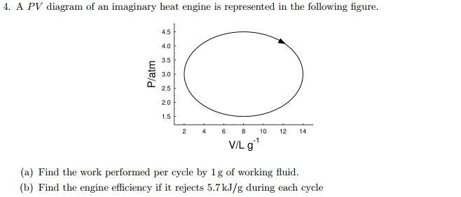

```python
display(Image(filename='./directions/4.jpg'))
```

The work performed per cycle is given by the area within the PV curve. $$ W_{performed} = \pi (14-8) (4.5-3.0) atm L g^{-1} $$ $$ W_{performed} = 9\pi atm L g^{-1} $$

as: $ 1 atm L = 101.3 J $

$$ W_{performed} = \frac{9117}{10} \pi J g^{-1} = 2864.190 J g^{-1}$$

$$ \eta_{engine} = \frac{W_{performed}}{W_{performed}+W_{rejected}} $$

$$ \eta_{engine} = \frac{2864.190 J g^{-1}}{2864.190 J g^{-1} + 5700 J g^{-1}} = 0.334 $$

## Exercise 5

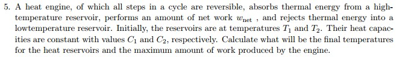

```python
display(Image(filename='./directions/5.jpg'))
```

The following is extracted from: Mungan, C. E. (2009). Heat engine with finite thermal reservoirs and nonideal efficiency. Latin-American Journal of Physics Education, 3(2), 239–242.

Let's denote some variables:  
$ dQ_H $ = heat transfer out of the hot reservoir  
$ dQ_C $ = heat transfer into the cold reservoir  
$ dW $ = work output by the engine  
$ dT_H $ = change in temperature of the hot reservoir ($ dT_H < 0$ as it's cooling down)  
$ T_{Ho} $ = $ T_1 $ = initial temperature of the hot reservoir  
$ dT_C $ = change in temperature of the cold reservoir ($ dT_C > 0$ as it warms up)  
$ T_{Co} $ = $ T_2 $ = initial temperature of the cold reservoir  
$ T $ = final temperature of both reservoirs  
$ \eta $ = 2nd law efficiency given

As both reservoirs have temperature-independent heat capacities $C_1$ and $C_2$, then it follows that: $$ dQ_H = -C_1 T_H $$ $$ dQ_C = C_2 T_C $$

The engine efficiency can be defined as: $$ \varepsilon = \frac{dW}{dQ_H} = 1 - \frac{dQ_C}{dQ_H} = 1 + \frac{dT_C}{dT_H} $$ With the following Carnot limiting efficiency: $$ \varepsilon_c = 1 - \frac{T_C}{T_H} $$

The 2nd law efficiency $\eta$ is assumed to be constant. $$ \eta = \frac{W_{net,out}}{Q_H} = \frac{Q_H - Q_C}{Q_H} = 1 - \frac{Q_C}{Q_H} $$

Rearranging terms, $T_C$ can be defined as a function of $T_H$: $$ T_H \frac{dT_C}{dT_H} + \eta T_C = (\eta - 1) T_H $$

The complementary solution of the previous is $A T_H^{-\eta}$ where $A$ is a constant to taylor the initial conditions. On the other hand, by trying a particular solution of the equation that is proportional to $T_H$, the following is obtained $(\eta - 1) T_H / (\eta + 1)$. Adding together these complementary and particular solutions and fitting to the initial temperatures of the two reservoirs gives: $$ \frac{T_C}{T_{\text{Ho}}}={\left(\frac{T_{\text{Ho}}}{T_H}\right)}^{\eta } \left\{\frac{T_{\text{Co}}}{T_{\text{Ho}}}+\frac{1 -\eta }{1 + \eta}\left(1-{\left(\frac{T_H}{T_{\text{Ho}}}\right)}^{\eta +1}\right)\right\} $$

Let's set $T_C = T_H = T$ to find the common final temperature of the two reservoirs: $$ \frac{T}{T_{Ho}} = {\left(\frac{(T_{Co} + T_{Ho}) + \eta (T_{Co} - T_{Ho})}{2 T_{Ho}}\right)}^{\frac{1}{1+\eta}} $$

$$ T = T_{Ho} {\left(\frac{(T_{Co} + T_{Ho}) + \eta (T_{Co} - T_{Ho})}{2 T_{Ho}}\right)}^{\frac{1}{1+\eta}} $$

where:  
$ T_{\min }=\sqrt{T_{\text{Co}} T_{\text{Ho}}} $ is the geometric average of the initial temperatures  
$ T_{\max }=\frac{T_{Co} + T_{Ho}}{2} $ is their aithmetic average

The total work output by the engine is the difference in heat transfers for the two reservoirs, as follows: $$ W = Q_H - Q_C = C_1(T_{Ho} - T) - C_2(T - T_{Co}) $$

And the maximum amount of work is given by:

$$ W_{max} = C_1 C_2 (T_{max} - T_{min}) $$

The maximum work is achieved for reversible operation of the engine when $\eta = 1$. On the other hand, zero work is output for maximally irreversible operation of the engine when $\eta = 0$.